# Challenge 3

Ryan Wesslen

July 27, 2016

#### Unsupervised machine learning

We’re going to run topic modeling on Tweets - the exception is we’re going to combine all users’ Tweets by each user, essentially running a user-level topic modeling.

1. First, read our Charlotte sample dataset and create the DFM object. Trim all words used less than 40 times.

```r
tweets <- read.csv('../datasets/CharlotteTweets20Sample.csv', stringsAsFactors=F)
source('../functions.R')

library(quanteda)
twcorpus <- corpus(tweets$body)
docvars(twcorpus, "actor.id") <- as.character(tweets$actor.id)
twdfm <- dfm(twcorpus, groups = "actor.id", ignoredFeatures = c(stopwords("english"), "t.co", "https", "rt", "amp", "http", "t.c", "can", "u"), removeTwitter = TRUE, ngrams=c(1,2))
```

```
## Creating a dfm from a corpus ...
##    ... grouping texts by variable: actor.id
##    ... lowercasing
##    ... tokenizing
##    ... indexing documents: 9,943 documents
##    ... indexing features: 341,460 feature types
##    ... removed 142,037 features, from 182 supplied (glob) feature types
##    ... created a 9943 x 199424 sparse dfm
##    ... complete.
## Elapsed time: 28.23 seconds.
```

```r
twdfm <- trim(twdfm, minDoc = 40)
```

```
## Removing features occurring in fewer than 40 documents: 198534
```

```r
topfeatures(twdfm)
```

```
##    charlotte           nc         just charlotte_nc         love
##         5618         3324         2126         2124         1483
##         like          get          day     carolina         time
##         1477         1365         1325         1239         1207
```

2. Now, estimate the topic model using a number of topics that you think is reasonable.

```r
# install.packages("topicmodels")
library(topicmodels)

# we now export to a format that we can run the topic model with
dtm <- convert(twdfm, to="topicmodels")

# estimate LDA with K topics
K <- 20
lda <- LDA(dtm, k = K, method = "Gibbs",
                control = list(verbose=25L, seed = 123, burnin = 100, iter = 500))
```

```
## K = 20; V = 890; M = 9434
## Sampling 600 iterations!
## Iteration 25 ...
## Iteration 50 ...
## Iteration 75 ...
## Iteration 100 ...
## Iteration 125 ...
## Iteration 150 ...
## Iteration 175 ...
## Iteration 200 ...
## Iteration 225 ...
## Iteration 250 ...
## Iteration 275 ...
## Iteration 300 ...
## Iteration 325 ...
## Iteration 350 ...
## Iteration 375 ...
## Iteration 400 ...
## Iteration 425 ...
## Iteration 450 ...
## Iteration 475 ...
## Iteration 500 ...
## Iteration 525 ...
## Iteration 550 ...
## Iteration 575 ...
## Iteration 600 ...
## Gibbs sampling completed!
```

```r
term <- terms(lda, 10)
colnames(term) <- paste("Topic",1:K)
term
```

```
##       Topic 1 Topic 2     Topic 3           Topic 4  Topic 5
##  [1,] "lol"   "charlotte" "drinking"        "like"   "love"
##  [2,] "like"  "gt"        "america"         "people" "much"
##  [3,] "shit"  "home"      "bank"            "just"   "please"
##  [4,] "got"   "place"     "stadium"         "know"   "im"
##  [5,] "fuck"  "hot"       "america_stadium" "never"  "guys"
##  [6,] "just"  "job"       "photo"           "really" "omg"
##  [7,] "even"  "know"      "beer"            "think"  "always"
##  [8,] "ass"   "hours"     "coffee"          "feel"   "follow"
##  [9,] "get"   "weather"   "good"            "say"    "get"
## [10,] "damn"  "monday"    "nice"            "ever"   "girl"
##       Topic 6       Topic 7          Topic 8   Topic 9
##  [1,] "time"        "happy"          "tonight" "right"
##  [2,] "new"         "day"            "party"   "now"
##  [3,] "hornets"     "birthday"       "live"    "want"
```

[output cut: 40 more lines]

3. Find the user with the highest topic probability in Topic 1. Extract the actor.id and then filter the original dataset to find all Tweets by the user.

How accurate was the topic to finding the “highest” user of the Tweets?

```r
# to get topic probabilities per actor ID (Twitter user)
postlist <- posterior(lda)
probtopics <- data.frame(postlist$topics)
#probtopics <- probtopics[,new.order]
colnames(probtopics) <- paste("Topic",1:K)

row <- order(-probtopics$`Topic 1`)
actorid <- rownames(probtopics[row[1],])
filter.data <- subset(tweets, actor.id == actorid)
```

4. Find a different topic. Find the top 5 users and similarly filter out their tweets.

How accurate were the Tweets to the topic? What other topics does the actor have a high probability (> 10%)? Do the users’ Tweets have some information related?

BONUS. Experiment with different number of topics. Which value appears to be more appropriate?

BONUS. BONUS. Use `KL.empirical` from the `entropy` library to calculate KL Divergence by user’s topic distributions. This will give a similarity measure (e.g., recommender) that will measure which users are most similar to this user.

```r
# install.packages("cvTools")
require(cvTools)

K <- c(5, 10, 20, 30, 40)

results <- list()

i = 1
for (k in K){
    cat("\n\n\n##########\n ", k, "topics", "\n")
    res <- cvLDA(k, dtm)
    results[[i]] <- res
    i = i + 1
}
```

[output not shown]

[output cut: 470 more lines]

[output not shown]

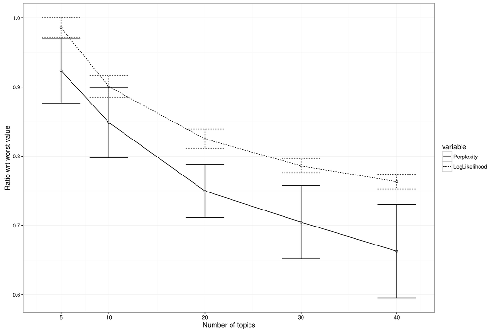

```r
topicPlots(results,K)
```